# 00_Data_Check_Visual

```r
library(tidyverse)
library(haven)
library(forcats)
library(ggplot2)
library(rlang)
library(descr)
library(mice)
library(ggridges)
```

```r
load("~/Hertie School/40_Masters_Thesis/Empirical/Raw_Data/consumer_level_metrics_all_respondents_ger.RData")


load("~/Hertie School/40_Masters_Thesis/Empirical/Raw_Data/meof_ger_df.RData")
```

# Consumer Metrics Data Check

```r
cm <- ger_consumer_level_metrics |>
  select(c(personid, total_visits_news_sites, total_visits_overall)) |>
  mutate(news_proportion = total_visits_news_sites / total_visits_overall)

cm <- cm |> select(personid, news_proportion)
```

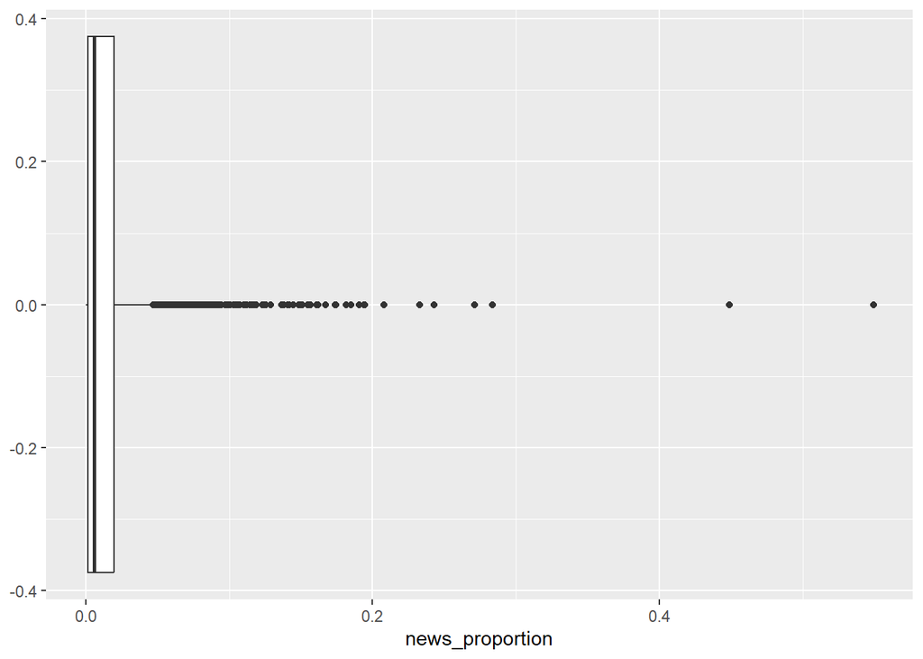

```r
cm |> ggplot(aes(news_proportion)) +
  geom_boxplot()
```

# Survey Data Check

## German Survey Data

*Might keep for analysis, not for ML

(**wave**)

1. wave* **1**
2. personid **1**
3. gender (**1**-8)
4. birthmonth (**1**)
5. birthyear (**1**)
6. age (**5**) - *We will use wave 5 because that’s the age of when they voted*
7. {voceduc (1,**2**) : ml_degreestatus} - *We will use wave 2 data here because its the most recent information*
8. {relationship (1,**2**): ml_relationship} - *We will use wave 2 data here because its the most recent information*
9. {maritalstatus (**1**): ml_married}
10. {employment (1,**2**): ml_employ} - *We will use wave 2 data here because its the most recent information*
11. hhincome (**2**)*
12. postcode *
13. {polinterest (1,**4**,6): ml_polinterest} - *We will use wave 4 data here because its the most recent information*
14. secondvote (**5**)

### **Selecting Columns**

**Wave 1 Variables: Respondent Details**

```r
baseline <- meof_ger_df |>
  select(wave, personid, gender, birthmonth, birthyear, maritalstatus, postcode) |>
  filter(wave == 1)

baseline <- baseline |>
  mutate(
    fgender = as_factor(gender),
    fmaritalstatus = as_factor(maritalstatus)
  )
```

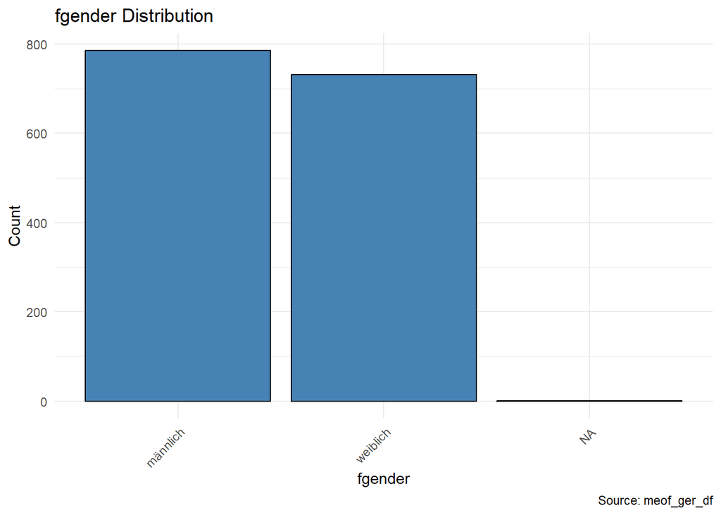

```r
explore <- function(data, list_of_columns) {
  plots <- list()  # Initialize an empty list to store the plots

  # Loop through each item in the list of columns
  for (item in list_of_columns) {

    # Check if the column is a factor or character variable (categorical)
    if (is.factor(data[[item]]) | is.character(data[[item]])) {
      # Convert to factor and explicitly include NAs as a separate level
      data[[item]] <- factor(data[[item]], exclude = NULL)

      img <- ggplot(data, aes(x = !!sym(item))) +
        geom_bar(fill = "steelblue", color = "black") +  # Normal bars for non-NA values
        # Add a red bar for NA values
        geom_bar(data = data %>% filter(is.na(!!sym(item))),
                 aes(x = "NA"), fill = "red", color = "black") +
        labs(
          title = paste(item, "Distribution"),
          x = item,
          y = "Count",
          caption = "Source: meof_ger_df"
        ) +
        theme_minimal() +
        theme(axis.text.x = element_text(angle = 45, hjust = 1))

    } else {
      # For numeric variables: Handle NA values separately
      # Replace NA values with a placeholder (e.g., "Missing")
      data[[item]] <- ifelse(is.na(data[[item]]), "Missing", as.character(data[[item]]))

      img <- ggplot(data, aes(x = !!sym(item))) +
        geom_bar(fill = "steelblue", color = "black") +  # Normal bars for non-NA values
        # Add a red bar for Missing values (treated as categorical)
        geom_bar(data = data %>% filter(!!sym(item) == "Missing"),
                 aes(x = !!sym(item)), fill = "red", color = "black") +
        labs(
          title = paste(item, "Distribution"),
          x = item,
          y = "Count",
          caption = "Source: meof_ger_df"
        ) +
        theme_minimal() +
        theme(axis.text.x = element_text(angle = 45, hjust = 1))
    }

    # Store each plot in the list
    plots[[item]] <- img
  }

  return(plots)  # Return the list of plots
}

list_of_columns <- c("fgender", "fmaritalstatus")
plots <- explore(baseline, list_of_columns)

# To display the plots, you can either print them one by one:
print(plots[["fgender"]])
```

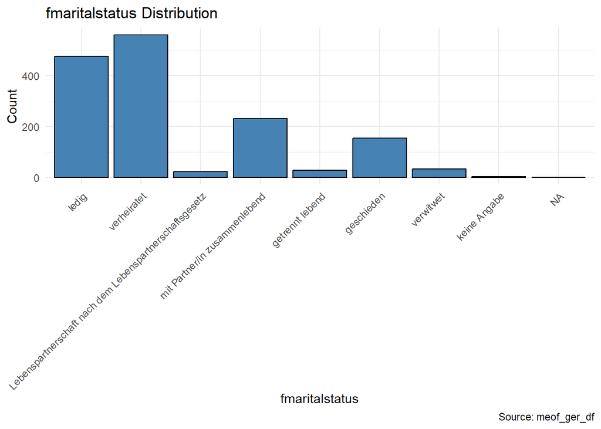

```r
print(plots[["fmaritalstatus"]])
```

**Wave 2 Variables: Respondent Details (Most Recent)**

```r
w2items <- meof_ger_df |>
  select(wave, personid, voceduc, relationship, employment) |>
  filter(wave == 2)

w2items <- w2items |>
  mutate(
    fvoceduc = as_factor(voceduc),
    frelationship = as_factor(relationship),
    femployment = as_factor(employment)
  )
```

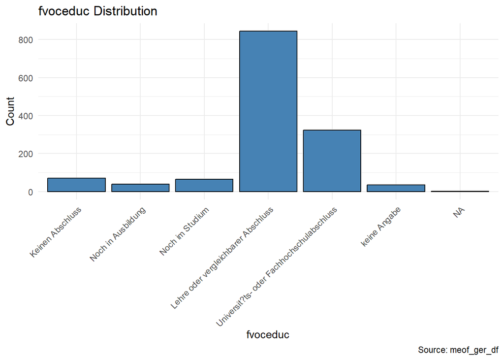

```r
list_of_columns <- c("fvoceduc", "frelationship", "femployment")
plots <- explore(w2items, list_of_columns)

# To display the plots, you can either print them one by one:
print(plots[["fvoceduc"]])
```

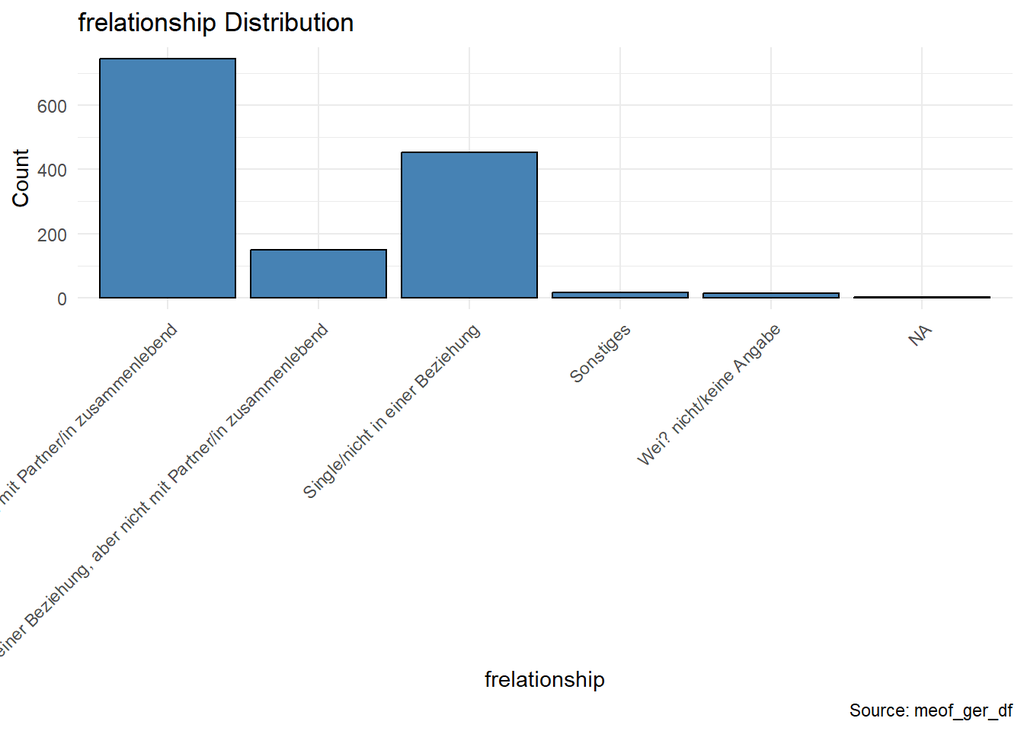

```r
print(plots[["frelationship"]])
```

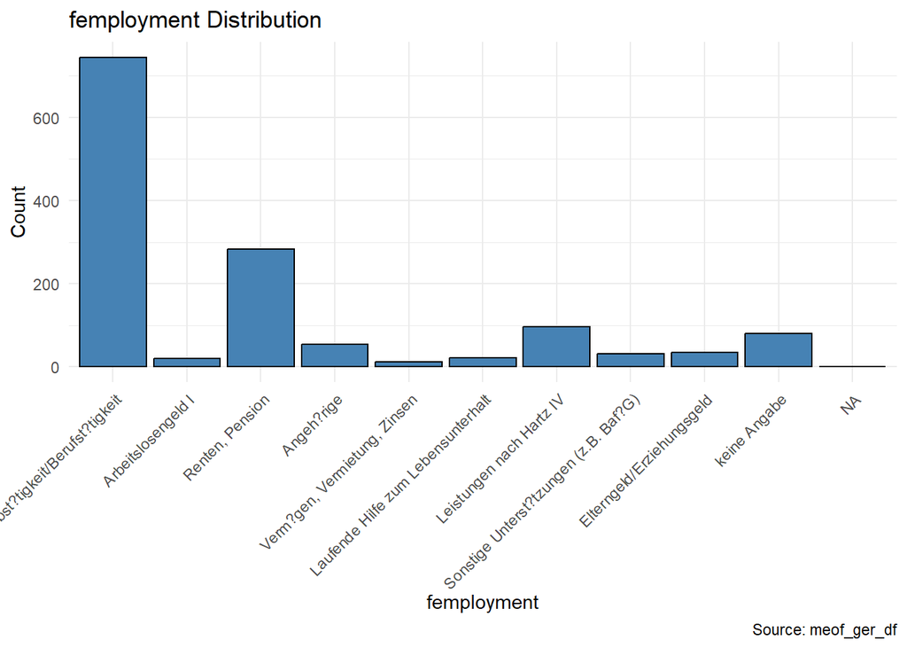

```r
print(plots[["femployment"]])
```

**Wave 4 Variable: Interest in Politics**

```r
polint <- meof_ger_df |>
  select(wave, personid, polinterest) |>
  filter(wave == 4)
```

```r
table(polint$polinterest)
```

```
##
##   1   2   3   4   5 977
##  38 114 367 392 303   1
```

```r
polint$polinterest <- na_if(polint$polinterest, 977)
```

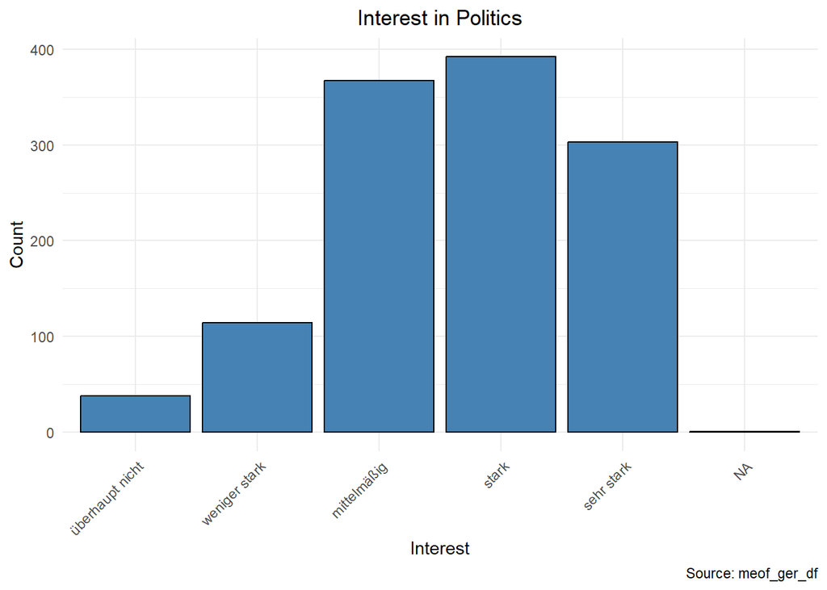

```r
polint |>
  mutate(polinterest = as_factor(polinterest)) |>
  ggplot(aes(x = polinterest)) +
  geom_bar(fill = "steelblue", color = "black") +
  labs(
    title = "Interest in Politics",
    x = "Interest",
    y = "Count",
    caption = "Source: meof_ger_df"
  ) +
  theme_minimal() +
  theme(
    axis.text.x = element_text(angle = 45, hjust = 1),
    plot.title = element_text(hjust = 0.5)
  )
```

**Wave 5 Variable: Voting Behavior**

```r
voting <- meof_ger_df |>
  filter(wave == 5, !is.na(voted_2017)) |>
  select(personid, age, secondvote)
```

```r
table(voting$secondvote)
```

```
##
##   1   2   3   4   5   6   7 977
## 225 265 115 109 217 173  88  17
```

```r
voting$secondvote <- na_if(voting$secondvote, 977)
voting$secondvote <- na_if(voting$secondvote, 7)
```

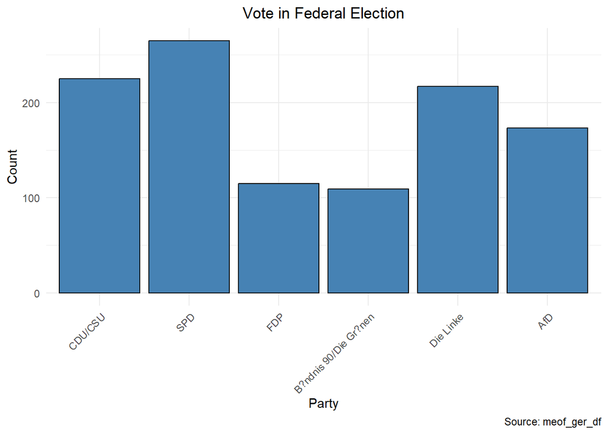

```r
voting |>
  filter(secondvote != 977 & secondvote != 7 & !is.na(secondvote)) |>
  mutate(secondvote = as_factor(secondvote)) |>
  ggplot(aes(x = secondvote)) +
  geom_bar(fill = "steelblue", color = "black") +
  labs(
    title = "Vote in Federal Election",
    x = "Party",
    y = "Count",
    caption = "Source: meof_ger_df"
  ) +
  theme_minimal() +
  theme(
    axis.text.x = element_text(angle = 45, hjust = 1),
    plot.title = element_text(hjust = 0.5)
  )
```

```r
voting <- voting |>
  mutate(
    adjustedvote = case_when(
      secondvote == 5 ~ -3,
      secondvote == 4 ~ -2,
      secondvote == 2 ~ -1,
      secondvote %in% c(7, 997) | is.na(secondvote) ~ 0,
      secondvote == 3 ~ 1,
      secondvote == 1 ~ 2,
      secondvote == 6 ~ 3,
      TRUE ~ 0
    ),
    adjustedvotelr = case_when(
      secondvote == 5 ~ -1,
      secondvote == 4 ~ -1,
      secondvote == 2 ~ -1,
      secondvote %in% c(7, 997) | is.na(secondvote) ~ 0,
      secondvote == 3 ~ 1,
      secondvote == 1 ~ 1,
      secondvote == 6 ~ 1,
      TRUE ~ 0
  ))
```

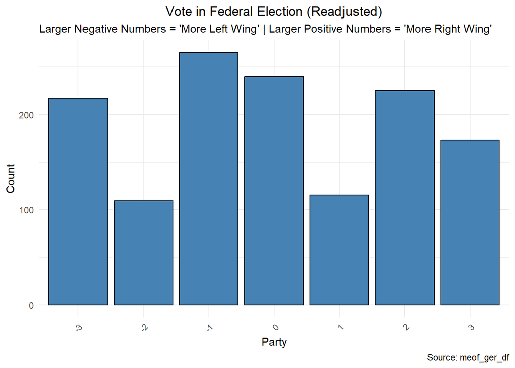

```r
voting |>
  ggplot(aes(x = factor(adjustedvote))) +  # Convert to factor to ensure all labels appear
  geom_bar(fill = "steelblue", color = "black") +
  labs(
    title = "Vote in Federal Election (Readjusted)",
    subtitle = "Larger Negative Numbers = 'More Left Wing' | Larger Positive Numbers = 'More Right Wing'",
    x = "Party",
    y = "Count",
    caption = "Source: meof_ger_df"
  ) +
  theme_minimal() +
  theme(
    plot.title = element_text(hjust = 0.5),
    axis.text.x = element_text(angle = 45, vjust = 1, hjust = 1)  # Rotate x labels for better readability
  )
```

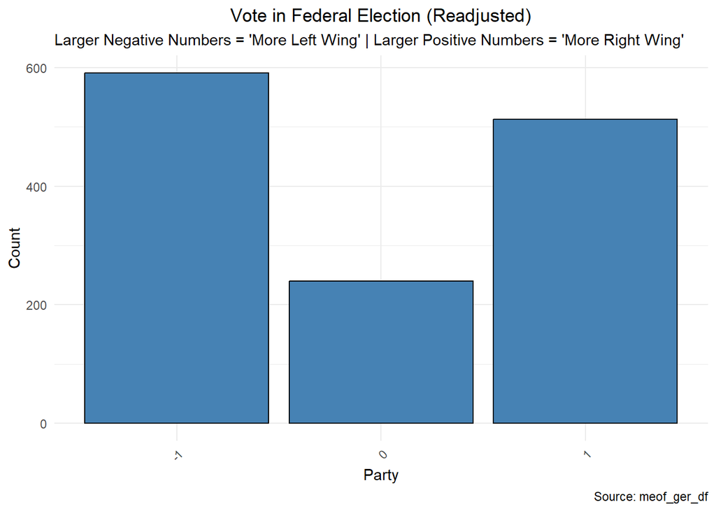

```r
voting |>
  ggplot(aes(x = factor(adjustedvotelr))) +  # Convert to factor to ensure all labels appear
  geom_bar(fill = "steelblue", color = "black") +
  labs(
    title = "Vote in Federal Election (Readjusted)",
    subtitle = "Larger Negative Numbers = 'More Left Wing' | Larger Positive Numbers = 'More Right Wing'",
    x = "Party",
    y = "Count",
    caption = "Source: meof_ger_df"
  ) +
  theme_minimal() +
  theme(
    plot.title = element_text(hjust = 0.5),
    axis.text.x = element_text(angle = 45, vjust = 1, hjust = 1)  # Rotate x labels for better readability
  )
```

**Wave 2 Variable: Income (Most Recent)**

```r
income <- meof_ger_df |>
  select(wave, personid, hhincome) |>
  filter(wave == 2) |>
  select(!wave)
```

```r
levels(income$hhincome)
```

```r
table(income$hhincome)
```

```
##
##   1   2   3   4   5   6   7   8   9  10  11  12  13
##  40 154 190 168 175 152 113  89  62  46  42   6 140
```

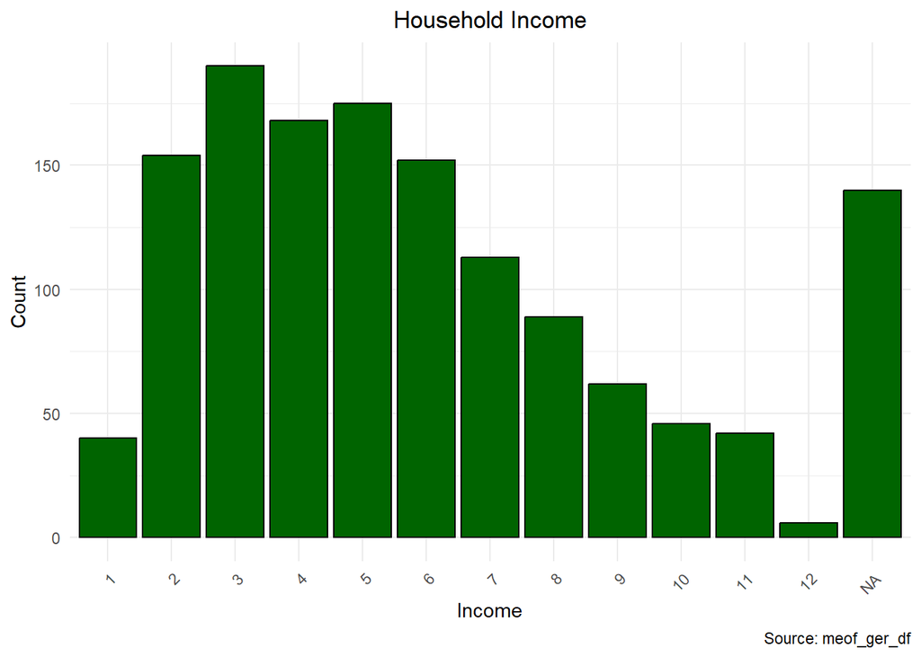

```r
income <- income |> mutate(
  hhincome = as.numeric(as.character(hhincome)),  # Ensure pincome is numeric
  adjustedincome = case_when(
    hhincome == 13 ~ NA,
    is.na(hhincome) ~ NA,
    TRUE ~ hhincome
  )
)

income |>
  ggplot(aes(x = factor(adjustedincome))) +  # Convert to factor for proper labeling
  geom_bar(fill = "darkgreen", color = "black") +
  labs(
    title = "Household Income",
    x = "Income",
    y = "Count",
    caption = "Source: meof_ger_df"
  ) +
  theme_minimal() +
  theme(
    plot.title = element_text(hjust = 0.5),
    axis.text.x = element_text(angle = 45, vjust = 1, hjust = 1)  # Rotate labels
  )
```

### Rejoining the Tables

```r
survey <- left_join(voting, baseline, by = "personid")

survey <- left_join(survey, cm , by = "personid")

survey <- left_join(survey, w2items, by = "personid")

survey <- left_join(survey, polint , by = "personid")

survey <- left_join(survey, income, by = "personid")
```

## Handling NA Values

Note: This is from 03_Survey_Tracking_Merging output.

```r
master <- read.csv("~/Hertie School/40_Masters_Thesis/Empirical/Processed_Data/31_merged_wide.csv")
```

```r
#survey <- survey |> filter(personid %in% master$personid | personid %in% nonews$personid)
```

```r
survey <- survey |>
  select(-wave.x, -wave.y) |>
  mutate(news_proportion = ifelse(is.na(news_proportion), 0, news_proportion))

# Count NAs per column
na_counts <- data.frame(sapply(survey, function(x) sum(is.na(x))))

# View the result
na_counts
```

```
##                 sapply.survey..function.x..sum.is.na.x...
## personid                                                0
## age                                                     0
## secondvote                                            240
## adjustedvote                                            0
## adjustedvotelr                                          0
## gender                                                  0
## birthmonth                                              0
## birthyear                                               0
## maritalstatus                                           0
## postcode                                               11
## fgender                                                 0
## fmaritalstatus                                          0
## news_proportion                                         0
## voceduc                                                74
## relationship                                           74
## employment                                             74
## fvoceduc                                               74
## frelationship                                          74
## femployment                                            74
## wave                                                  169
## polinterest                                           170
## hhincome                                               74
## adjustedincome                                        203
```

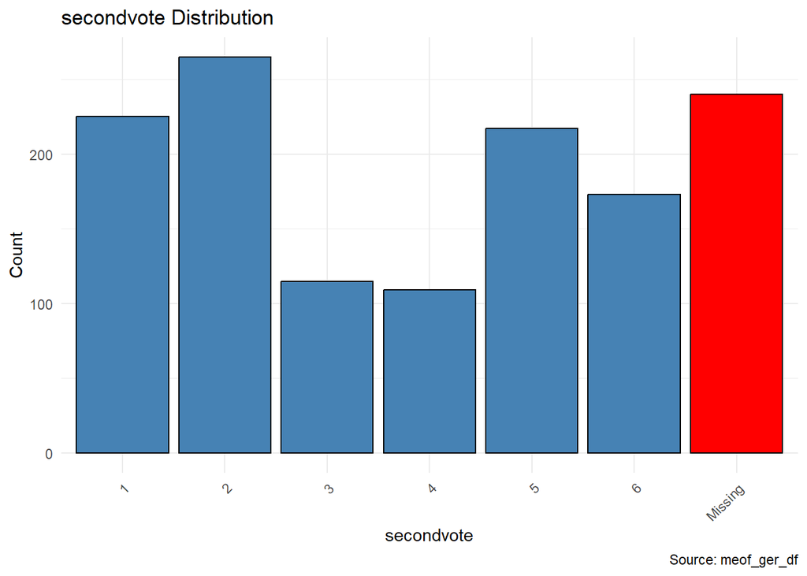

```r
# List of columns to plot
list_of_columns <- c("secondvote", "voceduc", "relationship", "employment",
                     "fvoceduc", "frelationship", "femployment",
                     "polinterest", "hhincome", "adjustedincome")

# Generate the plots
plots <- explore(survey, list_of_columns)

print(plots[["secondvote"]])
```

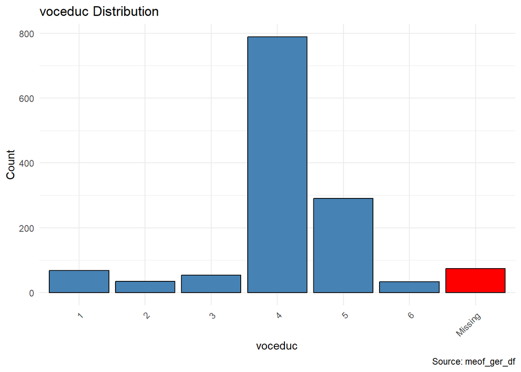

```r
print(plots[["voceduc"]])
```

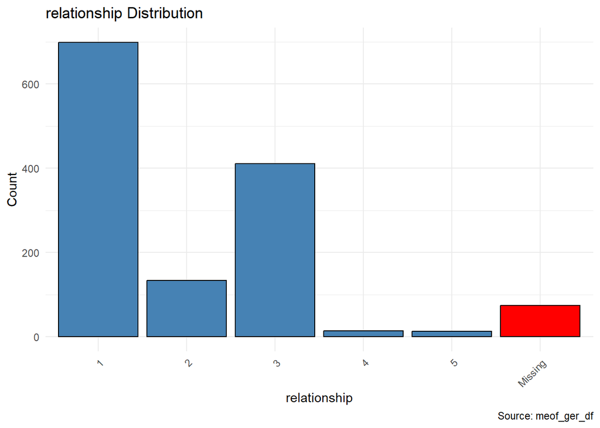

```r
print(plots[["relationship"]])
```

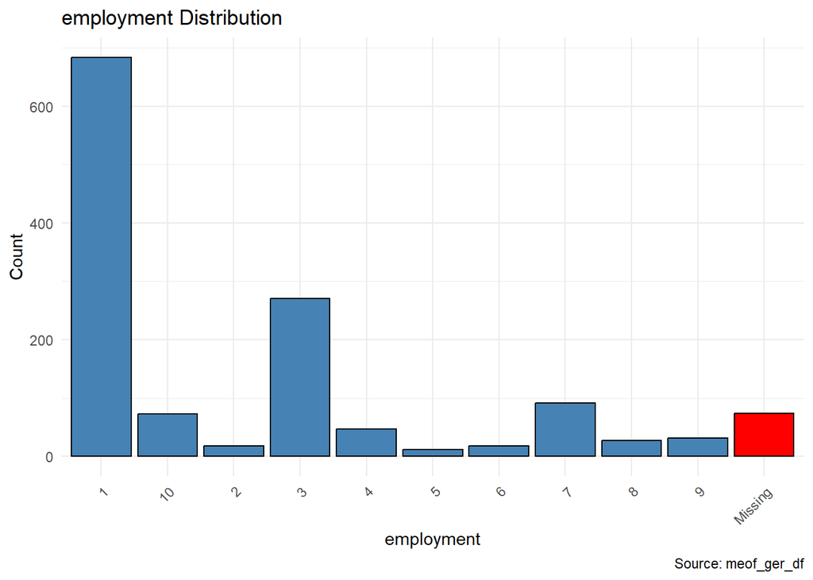

```r
print(plots[["employment"]])
```

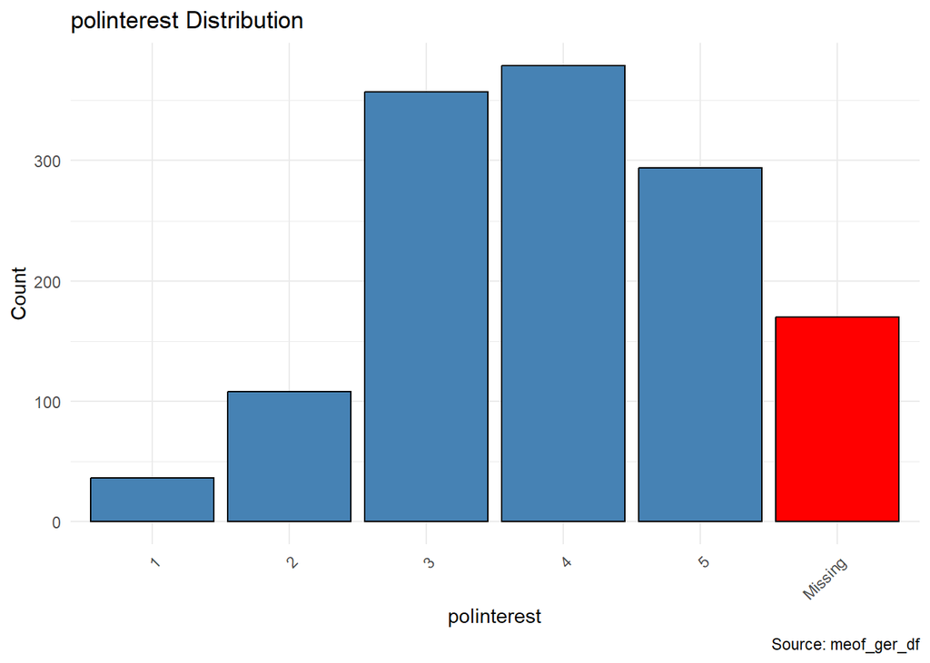

```r
print(plots[["polinterest"]])
```

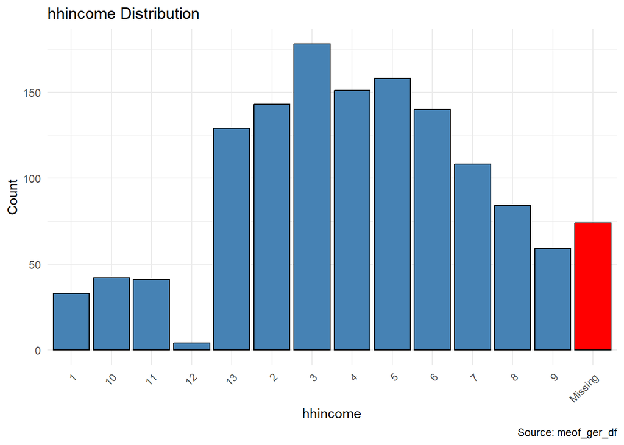

```r
print(plots[["hhincome"]])
```

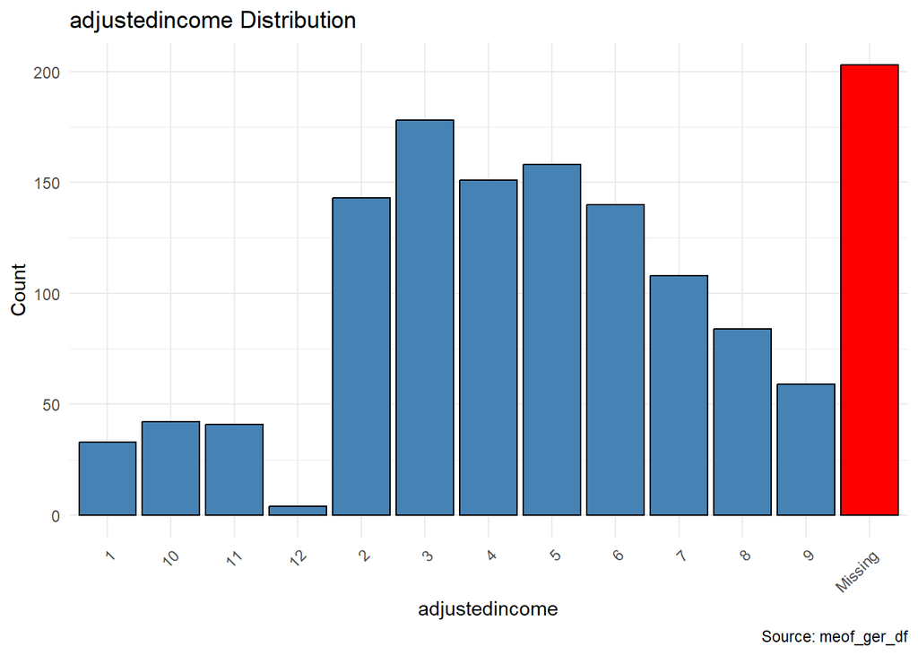

```r
print(plots[["adjustedincome"]])
```

```r
survey$secondvote[is.na(survey$secondvote)] <- 0

library(Hmisc)
# Impute missing values using the median for all columns in the dataset
imputed <- as.data.frame(lapply(survey, function(x) impute(x, fun = median)))
```

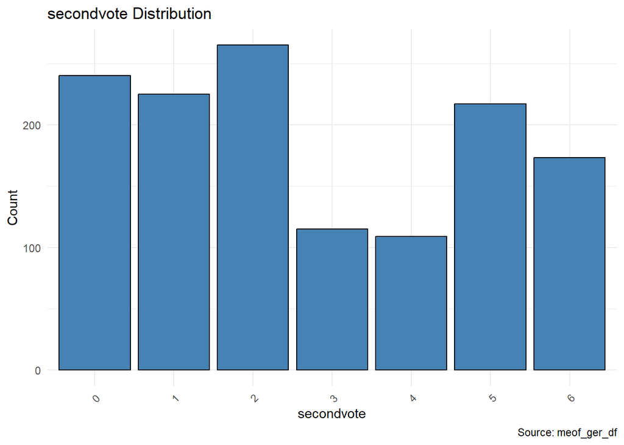

```r
# List of columns to plot
list_of_columns <- c("secondvote", "voceduc", "relationship", "employment",
                     "fvoceduc", "frelationship", "femployment",
                     "polinterest", "hhincome", "adjustedincome")

# Generate the plots
plots <- explore(imputed, list_of_columns)

print(plots[["secondvote"]])
```

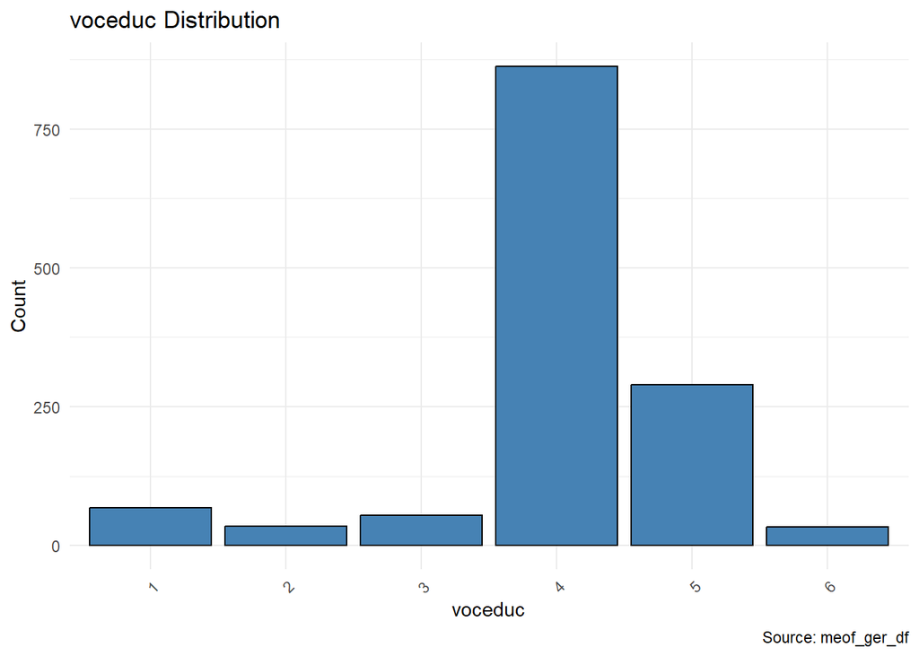

```r
print(plots[["voceduc"]])
```

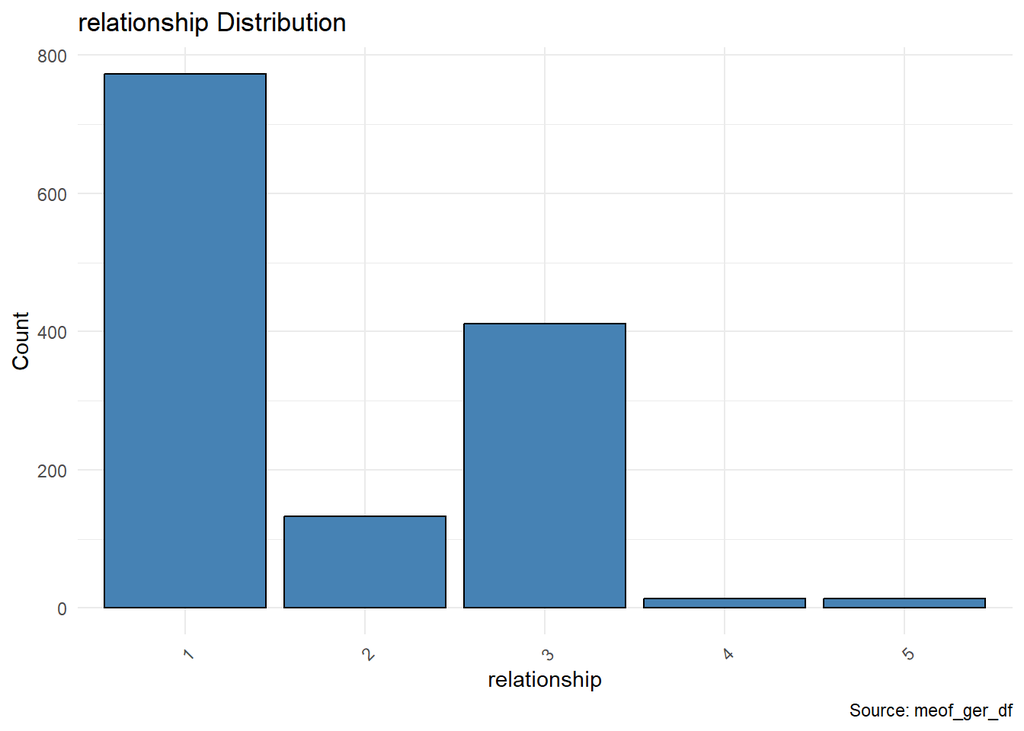

```r
print(plots[["relationship"]])
```

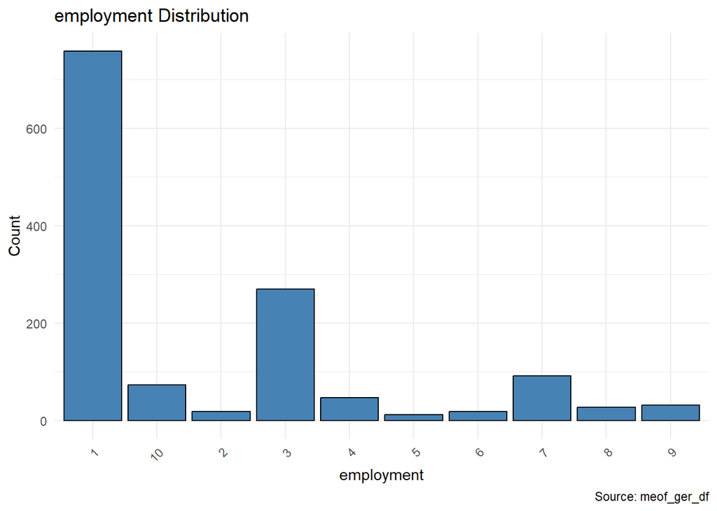

```r
print(plots[["employment"]])
```

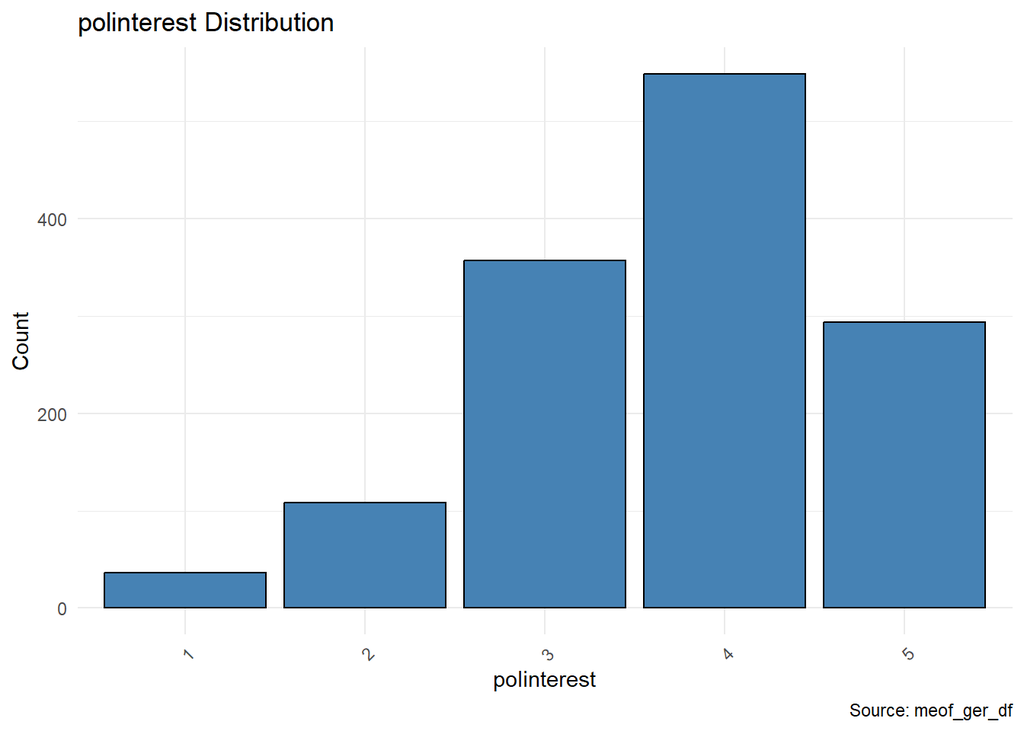

```r
print(plots[["polinterest"]])
```

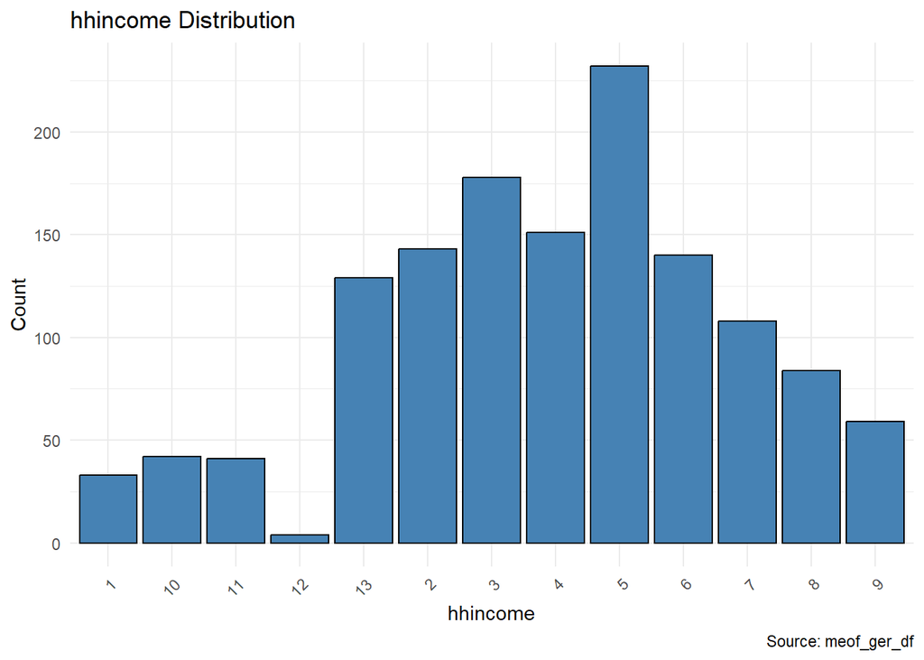

```r
print(plots[["hhincome"]])
```

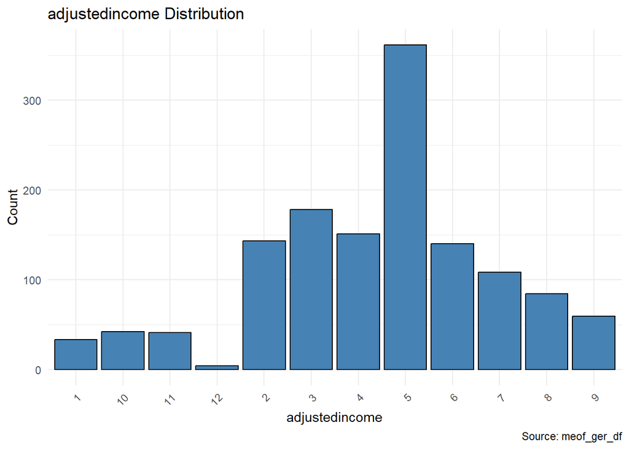

```r
print(plots[["adjustedincome"]])
```

```r
# Count NAs per column
na_post <- data.frame(sapply(imputed, function(x) sum(is.na(x))))

# View the result
na_post
```

```
##                 sapply.imputed..function.x..sum.is.na.x...
## personid                                                 0
## age                                                      0
## secondvote                                               0
## adjustedvote                                             0
## adjustedvotelr                                           0
## gender                                                   0
## birthmonth                                               0
## birthyear                                                0
## maritalstatus                                            0
## postcode                                                 0
## fgender                                                  0
## fmaritalstatus                                           0
## news_proportion                                          0
## voceduc                                                  0
## relationship                                             0
## employment                                               0
## fvoceduc                                                 0
## frelationship                                            0
## femployment                                              0
## wave                                                     0
## polinterest                                              0
## hhincome                                                 0
## adjustedincome                                           0
```

# Visualizing Relationships

```
## Defaulting to continuous.
```

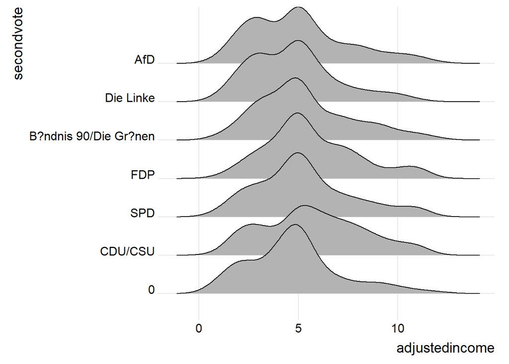

```r
imputed |>
  mutate(secondvote = as_factor(secondvote)) |>
  filter(secondvote != "Andere Partei" & secondvote != "977") |>
  ggplot(aes(x = adjustedincome, y = secondvote)) +
  geom_density_ridges() +
  theme_ridges() +
  theme(legend.position = "none")
```

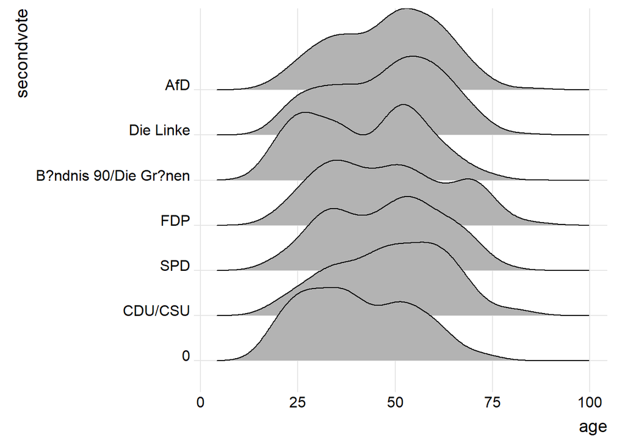

```r
imputed |>
  mutate(secondvote = as_factor(secondvote)) |>
  filter(secondvote != "Andere Partei" & secondvote != "977") |>
  ggplot(aes(x = age, y = secondvote)) +
  geom_density_ridges() +
  theme_ridges() +
  theme(legend.position = "none")
```

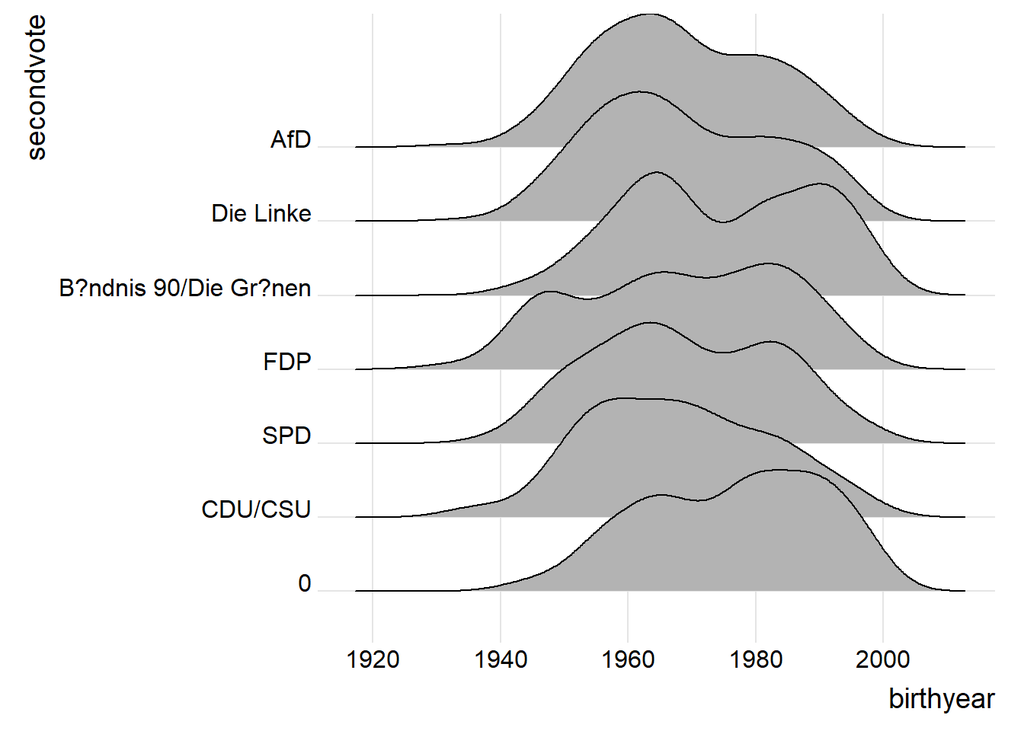

```r
imputed |>
  mutate(secondvote = as_factor(secondvote)) |>
  filter(secondvote != "Andere Partei" & secondvote != "977") |>
  ggplot(aes(x = birthyear, y = secondvote)) +
  geom_density_ridges() +
  theme_ridges() +
  theme(legend.position = "none")
```

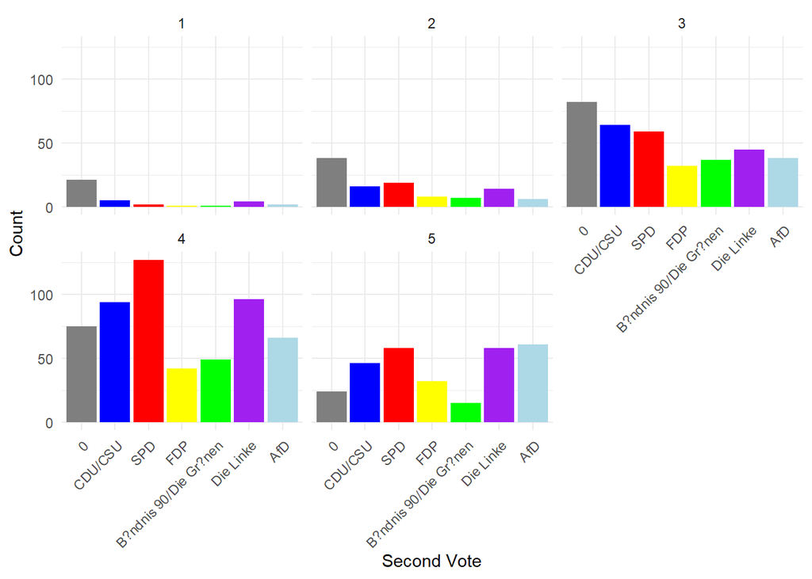

```r
imputed |>
  mutate(
    secondvote = as_factor(secondvote),
    polinterest = as.factor(polinterest)
  ) |>  # Ensure polinterest is a factor
  filter(secondvote != "Andere Partei" & secondvote != "977") |>  # Filter out specific secondvote values
  ggplot(aes(x = secondvote, fill = secondvote)) +  # Use secondvote for x-axis and fill by secondvote
  geom_bar(aes(y = after_stat(count)), position = "dodge") +  # Position bars side by side
  facet_wrap(~polinterest) +  # Create facets for each level of polinterest
  scale_fill_manual(
    values = c(
      "AfD" = "lightblue",
      "Die Linke" = "purple",
      "FDP" = "yellow",
      "SPD" = "red",
      "CDU/CSU" = "blue",
      "B?ndnis 90/Die Gr?nen" = "green",
      "Other" = "gray"  # Color for all other categories
    )
  ) +
  theme_minimal() +  # Use a minimal theme for clarity
  theme(
    legend.position = "none",  # Remove the legend
    axis.text.x = element_text(angle = 45, hjust = 1)  # Rotate x-axis labels for better readability
  ) +
  labs(x = "Second Vote", y = "Count")  # Add axis labels
```

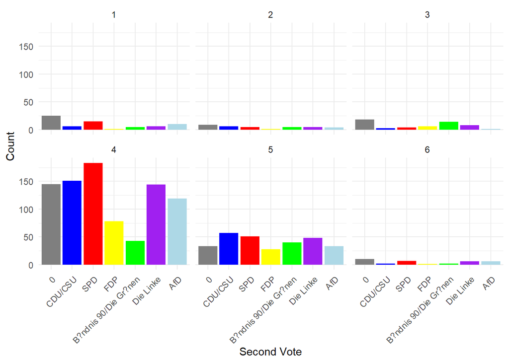

```r
imputed |>
  mutate(
    secondvote = as_factor(secondvote),
    polinterest = as_factor(voceduc)
  ) |>  # Ensure polinterest is a factor
  filter(secondvote != "Andere Partei" & secondvote != "977") |>  # Filter out specific secondvote values
  ggplot(aes(x = secondvote, fill = secondvote)) +  # Use secondvote for x-axis and fill by secondvote
  geom_bar(aes(y = after_stat(count)), position = "dodge") +  # Position bars side by side
  facet_wrap(~voceduc) +  # Create facets for each level of polinterest
  scale_fill_manual(
    values = c(
      "AfD" = "lightblue",
      "Die Linke" = "purple",
      "FDP" = "yellow",
      "SPD" = "red",
      "CDU/CSU" = "blue",
      "B?ndnis 90/Die Gr?nen" = "green",
      "Other" = "gray"  # Color for all other categories
    )
  ) +
  theme_minimal() +  # Use a minimal theme for clarity
  theme(
    legend.position = "none",  # Remove the legend
    axis.text.x = element_text(angle = 45, hjust = 1)  # Rotate x-axis labels for better readability
  ) +
  labs(x = "Second Vote", y = "Count")  # Add axis labels
```

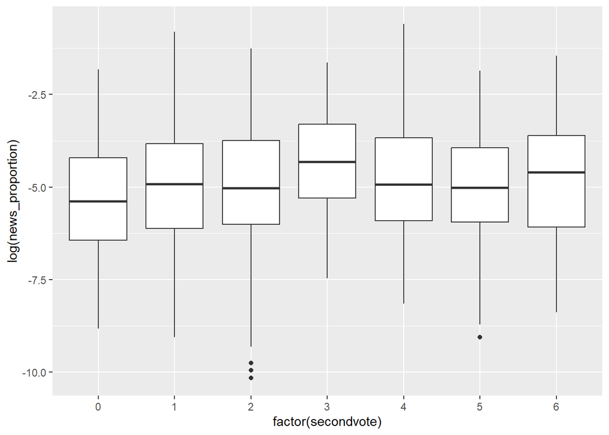

```r
imputed |>
  ggplot(aes(x = factor(secondvote), y = log(news_proportion))) +
  geom_boxplot()
```

# Write to CSV

```r
imputed |> write.csv("~/Hertie School/40_Masters_Thesis/Empirical/Processed_Data/00_labeled_survey.csv", row.names = FALSE)
```